# Model for numerical choice scenarios (experiments 1 to 3)

2023-04-08

```r
# ensure this script returns the same results on each run
set.seed(8726)
```

## Explaining the model

```r
# Imagine a situation in which answers range from 1000 to 2000
range <- 1000
# and a population of n = 999
population <- 999
# and we observe samples of 3
sample <- 3
# alpha and beta values for beta distributions modelling competence
alpha <- 1
beta <- 1
# ramge of values for estimates
min_range = 1000
max_range = 2000

# set arbitrary limit for competence distribution
# (factor determining distance between lowest and highest possible competence,
# i.e. standard deviation)
competence_ratio = 1000
```

### Define competence and its distribution

We define competence as the value of the standard deviation from which one’s answer is drawn. We suppose that answers for all individuals are drawn from normal distributions. Each individual has their own normal distribution. All normal distributions are centered around the true answer, but they differ in their standard deviations. The higher the competence, the lower the standard deviation, i.e. the more certain a guess drawn from the normal distribution will be close to the true answer.

We (arbitrarily) set the *lowest* competence to the range of possible values, in our case 2000 - 1000 = 1000. We set the *highest* competence to 1/1000 of the range of possible values, in our case 1.

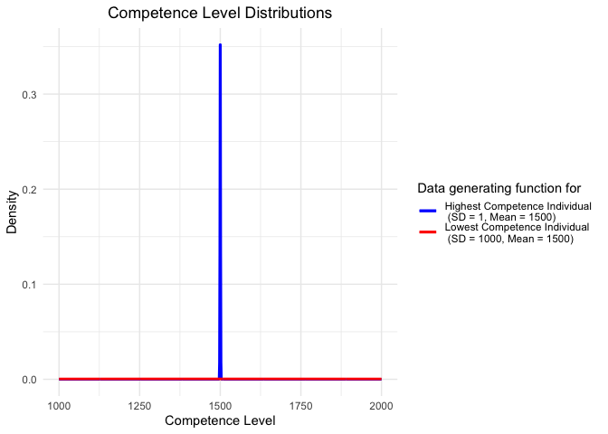

```r
# Define the x-axis values
x <- seq(1000, 2000, length.out = 1000)

# Define the PDFs for the two distributions
high_competence_pdf <- dnorm(x, mean = 1500, sd = 1)
low_competence_pdf <- dnorm(x, mean = 1500, sd = 1000)

# Create the plot
ggplot() +
  geom_line(aes(x, high_competence_pdf, color = "Highest Competence Individual \n (SD = 1, Mean = 1500)"), size = 1) +
  geom_line(aes(x, low_competence_pdf, color = "Lowest Competence Individual \n (SD = 1000, Mean = 1500)"), size = 1) +
  labs(x = "Competence Level", y = "Density", color = "Data generating function for") +
  ggtitle("Competence Level Distributions") +
  scale_color_manual(values = c("Highest Competence Individual \n (SD = 1, Mean = 1500)" = "blue",
                                "Lowest Competence Individual \n (SD = 1000, Mean = 1500)" = "red")) +
  theme_minimal() +
  theme(plot.title = element_text(hjust = 0.5))
```

We assume that individuals (i) vary in competence and (ii) that the distribution of competence in the population varies, as can be modeled by a beta distribution. In the case below, we assume a uniform competence distribution (equal to a beta distribution of alpha = 1 and beta = 1).

In order to be able to compare competence measures across different ranges, we want to scale it to reach from 0 (minimal competence) to 1 (maximal competence).

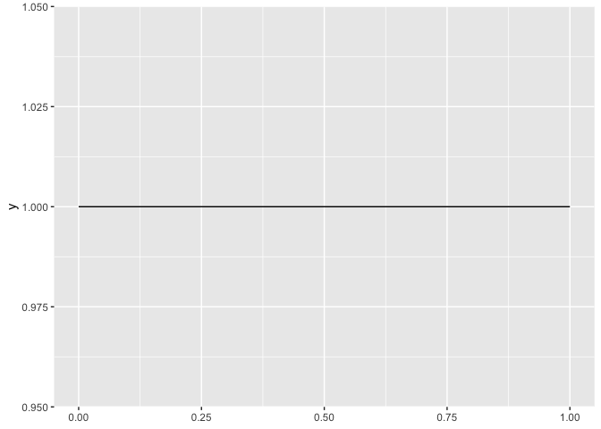

```r
# 1: Distribution of competence

# Theoretical population distribution of competence
ggplot() +
  geom_function(fun = ~dbeta(.x, shape1 = 1, shape2 = 1))
```

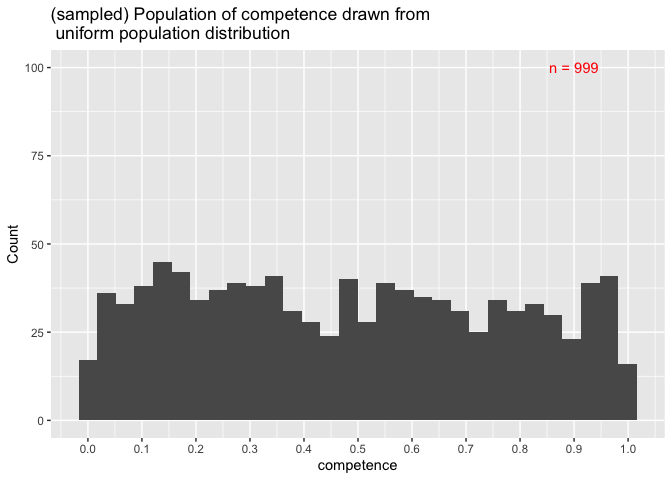

```r
# randomly draw competence levels
data <- tibble(id = 1:population,
               competence = rbeta(population, shape1 = alpha,
                                          shape2 = beta)) %>%
    # For now competence tending towards one is more competent.
    # For the data generating, we need the reverse and scale this competence measure.
    mutate(
      # Since competence = standard deviation of estimate generating normal distribution,
      # reverse the scale such that 0 corresponds to maximal competence (instead of 1).
      competence_reversed = 1 - competence,
      # Put values on a scale:
      # We (arbitrarily) set the lowest competence to the range of possible values,
      # in case of our experiments 2000 - 1000 = 1000.
      # We set the highest competence to 1/1000 of the range of possible values,
      # in our case 1.
      competence_reversed_scaled = (competence_reversed * range) + range/competence_ratio)


# generated population
ggplot(data, aes(x = competence)) +
  geom_histogram() +
  scale_x_continuous(breaks = seq(from = 0, to = 1, by = 0.1)) +
  annotate("text", x = 0.9, y = 100, label = paste0("n = ", population), color = "red") +
  labs(title = "(sampled) Population of competence drawn from \n uniform population distribution",
       y = "Count")
```

### Generate a choice for each individual based on their competence.

The numbers that we generate from the normal distributions are truncated such that they all lie within the pre-defined range (1000 to 2000)

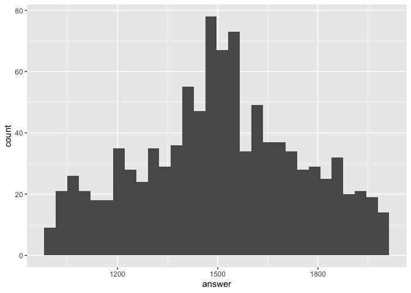

```r
# 2: Draw individual answers based on competence levels
mean <- 1500

# use the reversed competence variable to generate the estimates
data$answer <- data$competence_reversed_scaled %>%
  purrr::map_dbl(function(x){

    sd <- x

    answer = truncnorm::rtruncnorm(1, mean = mean, sd = sd, a = min_range, b = max_range)
  }
  )

ggplot(data, aes(x = answer)) +
  geom_histogram()
```

### Measure accuracy

We measure accuracy as the (squared) distance between the chosen answer and the true answer for each individual.

We let this distance be negative, such that higher values represent higher accuracy.

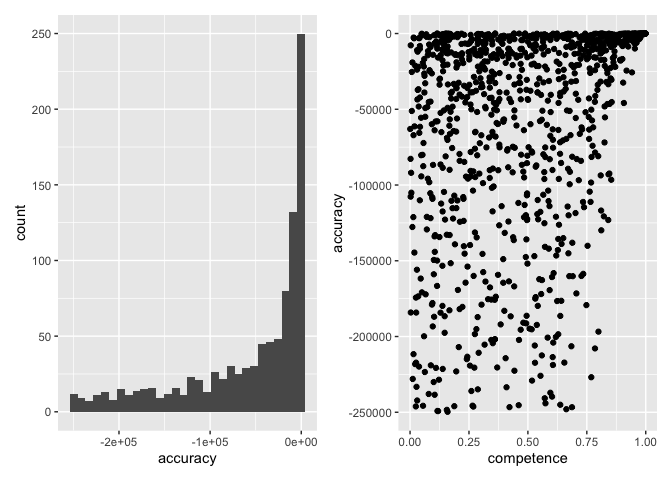

```r
# 3: measure accuracy
data <- data %>%
  mutate(accuracy = -1 * (mean - answer)^2)

ggplot(data, aes(x = accuracy)) +
  geom_histogram() +

ggplot(data, aes(x = competence, y = accuracy)) +
  geom_point()
```

### Draw samples, calculate convergence & compare average outcomes

### Randomly draw samples from the population

```r
# 4: randomly assign samples in population
data <- data %>% mutate(sample_id = rep(1:(population/sample), sample))
```

### Calculate convergence

We define convergence as the standard deviation of the answers within a sample (multiplied by -1 so that higher values correspond to greater convergence)

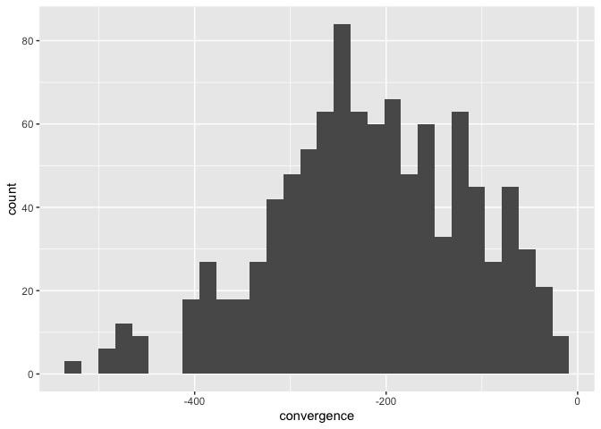

```r
# 5: calculate convergence
data <- data %>%
  # identify how often a one type of answer occurs in one group
  group_by(sample_id) %>%
  mutate(convergence = -1 * sd(answer)) %>%
  ungroup()

ggplot(data, aes(x = convergence)) +
  geom_histogram()
```

### Compute average accuracy/competence per sample.

```r
# 6: calculate accuracy and competence per sample

# compute the summary statistics for each sample
results <- data %>%
  group_by(sample_id, convergence) %>%
  summarize(competence_mean = mean(competence),
            accuracy_mean = mean(accuracy)) %>%
  # store simulation information
  mutate(population = population,
         sample = sample)
```

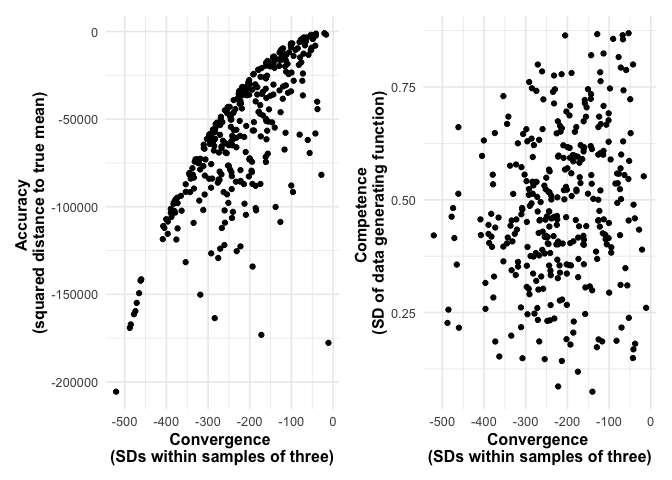

```r
accuracy_plot <- ggplot(results, aes(x = convergence, y = accuracy_mean)) +
  geom_point() +
  # Add nice labels
    labs(x = "Convergence \n(SDs within samples of three)",
         y = "Accuracy \n(squared distance to true mean)") +
  plot_theme

competence_plot <- ggplot(results, aes(x = convergence, y = competence_mean)) +
  geom_point() +
  # Add nice labels
    labs(x = "Convergence \n(SDs within samples of three)",
         y = "Competence \n(SD of data generating function)") +
  plot_theme

accuracy_plot + competence_plot
```

## Functions

### Data generating functions

#### Vary sample size

This function allows us to investigate how accuracy and competence change with varying the sample size.

### Plot functions

#### c) Plot competence distributions

We want to plot the underlying competence distributions.

```r
# Plot competence distributions
plot_competence_distributions <- function(data) {
  # Your data frame
  d <- data %>%
    group_by(competence) %>%
    reframe(alpha = unique(alpha), beta = unique(beta))

  # Function to plot the different competence distributions
  plot_competence_distributions <- function(alpha, beta) {
    ggplot() +
      geom_function(
        fun = ~dbeta(.x, shape1 = alpha, shape2 = beta)
      ) +
      labs(title = paste0("alpha = ", alpha, ", beta = ", beta),
           y = "Density", x = "Competence") +
      plot_theme
  }

  # Specify the values of alpha and beta from the data
  alpha_values <- d$alpha
  beta_values <- d$beta

  # Create a list of ggplot objects
  plot_list <- map2(alpha_values, beta_values, plot_competence_distributions)

  # Arrange and display the plots
  competence_plot <- ggarrange(plotlist = plot_list) %>%
    ggpubr::annotate_figure(top = ggpubr::text_grob("Competence distributions",
                                                    face = "bold",
                                                    color = "darkgrey",
                                                    size = 14))


  return(competence_plot)
}
```

#### d) Plot varying competence distributions by sample

Fourth, we want another function that plots results by various competence levels by sample sizes.

```r
plot_competence <- function(data, outcome = "accuracy") {

  d <- data

  # extract simulation info
  caption = paste0("Sample size of informants: ", d$sample[1],
                     "; Iterations per sample size: ", d$total_iterations[1],
                     "; Population size per iteration: ", d$population[1])


  plot_accuracy <- ggplot(d, aes(x = convergence, y = accuracy_mean)) +
    geom_hex(alpha = 0.9) +
    #geom_smooth(method = "lm", se = FALSE) +
    stat_smooth(geom='line', method = "lm", alpha=0.7, se=FALSE, color = "darkgrey") +
    # Add nice labels
    labs(x = "Convergence \n(SDs of samples)",
         y = "Accuracy \n(squared distance to true mean)",
         caption = caption) +
  scale_fill_viridis_c(option = "plasma", begin = 0.1) +
    facet_wrap(~competence) +
    plot_theme +
    theme(legend.position = "top")

  plot_competence <- ggplot(d, aes(x = convergence, y = competence_mean)) +
    geom_hex(alpha = 0.9) +
    #geom_smooth(method = "lm", se = FALSE) +
    stat_smooth(geom='line', method = "lm", alpha=0.7, se=FALSE, color = "darkgrey") +
    # Add nice labels
    labs(x = "Convergence \n(SDs of samples)",
         y = "Competence \n(SD for data generating function)",
         caption = caption) +
  scale_fill_viridis_c(option = "plasma", begin = 0.1) +
    facet_wrap(~competence) +
    plot_theme +
    theme(legend.position = "top")

  if (outcome == "accuracy") {

    return(plot_accuracy)
  }

  if (outcome == "competence") {

    return(plot_competence)
  }
}

plot_competence_vary <- function(data, ...) {

  # get different samples as vector
  samples <- data %>%
    reframe(unique(as.character(sample))) %>% pull()


  # empty list
  plot_list <- list()

  # make plots fro each moderator
  for (i in samples) {

    plot_data <- data %>%
      filter(sample == i)

    sample_plot <- plot_competence(data = plot_data, ...)

    plot_list[[i]] <- sample_plot
  }

  return(plot_list)
}

plot_competence_vary_relative_majority <- function(data, variable = options, outcome = "Accuracy") {

  d <- data

  # Extract variable name as a string
  variable_name <- deparse(substitute(variable))

  # retrieve info from choice of variable
  if (variable_name == "options") {
    caption = paste0("Sample size of informants: ", d$sample[1],
                     "; Iterations per sample size: ", d$total_iterations[1],
                     "; Population size per iteration: ", d$population[1])
  }
  if (variable_name == "sample") {
    caption = paste0("Number of choice options: ", d$options[1],
                     "; Iterations per sample size: ", d$total_iterations[1],
                     "; Population size per iteration: ", d$population[1])
  }

  d <- d %>%
    group_by(relative_majority, {{variable}}, competence) %>%
    summarise(competence_mean = mean(average_relative_competence),
              accuracy_mean = mean(average_accuracy),
              accuracy_sd = sd(average_accuracy),
              competence_sd = sd(average_relative_competence)
    )

  # Assign outcome variable
  if(outcome == "Accuracy") {
    d$outcome <- d$accuracy_mean
    d$outcome_sd <- d$accuracy_sd
  }

  if(outcome == "Competence") {
    d$outcome <- d$competence_mean
    d$outcome_sd <- d$competence_sd
  }

  plot_outcome <- ggplot(d,
                         aes(x = relative_majority, y = outcome,
                             color = as.factor({{variable}}))) +
    geom_point() +
    geom_line() +
    # Add nice labels
    labs(x = "Relative majority \n (share of informants agreeing on an option)",
         y = outcome, caption = caption,
         color = variable_name) +
    scale_color_viridis_d(option = "plasma", begin = 0.1,
                          #limits = rev(levels(d$constellation)),
                          direction = -1
    ) +
    facet_wrap(~competence) +
    plot_theme +
    theme(legend.position = "top")

   return(plot_outcome)

}
```